# Fishes of Carpinteria Salt Marsh

Annual monitoring, 2012–2025

Biology of Fishes Course

October 26, 2026

```r
# Load required packages
library(tidyverse)
library(scales)
library(viridis)
library(knitr)
library(kableExtra)
library(ggridges)
library(patchwork)

# Interactive visualization packages
library(plotly)
library(highcharter)
library(DT)
library(crosstalk)
library(htmltools)

# Set theme for all plots
theme_set(theme_minimal(base_size = 12) +
 theme(
   plot.title = element_text(face = "bold", size = 14),
   plot.subtitle = element_text(color = "gray40"),
   legend.position = "bottom",
   panel.grid.minor = element_blank()
 ))

# Custom color palette for fish families
fish_colors <- c(
 "Gobiidae" = "#1f77b4",
 "Atherinopsidae" = "#ff7f0e",
 "Fundulidae" = "#2ca02c",
 "Paralichthyidae" = "#d62728",
 "Syngnathidae" = "#9467bd",
 "Embiotocidae" = "#8c564b",
 "Cottidae" = "#e377c2",
 "Other" = "#7f7f7f"
)

# Publication-quality Highcharter theme
hc_theme_csm <- hc_theme(
 colors = c("#2171b5", "#cb181d", "#238b45", "#fe9929", "#6a51a3", "#41b6c4"),
 chart = list(
   backgroundColor = "#ffffff",
   style = list(fontFamily = "Helvetica Neue, Arial, sans-serif")
 ),
 title = list(style = list(
   fontWeight = "600",
   fontSize = "16px",
   color = "#1a1a1a"
 )),
 subtitle = list(style = list(
   color = "#666666",
   fontSize = "12px"
 )),
 xAxis = list(
   lineColor = "#333333",
   tickColor = "#333333",
   labels = list(style = list(color = "#333333", fontSize = "11px")),
   title = list(style = list(color = "#333333", fontSize = "12px", fontWeight = "500"))
 ),
 yAxis = list(
   gridLineColor = "#e6e6e6",
   lineColor = "#333333",
   labels = list(style = list(color = "#333333", fontSize = "11px")),
   title = list(style = list(color = "#333333", fontSize = "12px", fontWeight = "500"))
 ),
 legend = list(
   itemStyle = list(color = "#333333", fontSize = "11px"),
   itemHoverStyle = list(color = "#1a1a1a")
 ),
 tooltip = list(
   backgroundColor = "rgba(255,255,255,0.95)",
   borderColor = "#cccccc",
   borderRadius = 4,
   style = list(fontSize = "12px")
 ),
 credits = list(enabled = FALSE)
)
```

# 1 Introduction

## 1.1 The Carpinteria Salt Marsh

```r
# Interactive map using leaflet
library(leaflet)

leaflet() %>%
 addProviderTiles(providers$Esri.WorldImagery) %>%
 setView(lng = -119.538, lat = 34.401, zoom = 14) %>%
 addMarkers(
   lng = -119.538, lat = 34.401,
   popup = "<b>Carpinteria Salt Marsh</b><br>~230 acres of coastal wetland<br>Santa Barbara County, CA"
 ) %>%
 addScaleBar(position = "bottomleft")
```

[interactive chart not shown]

**Carpinteria Salt Marsh** is a ~230-acre coastal wetland located in Santa Barbara County, California. It represents one of the few remaining relatively undisturbed tidal wetlands along the Southern California coast and serves as critical habitat for numerous fish species.

### 1.1.1 Why Study Salt Marsh Fishes?

Salt marshes provide essential ecosystem services:

- **Nursery habitat** for juvenile fishes of commercial and recreational importance
- **Foraging grounds** for resident species adapted to fluctuating conditions
- **Refugia** from predators in shallow, vegetated waters
- **Productivity hotspots** supporting complex food webs

### 1.1.2 Data Source

This report analyzes data from the **SONGS (San Onofre Nuclear Generating Station) Mitigation Monitoring Program** collected by UC Santa Barbara’s Marine Science Institute from **2012-2025**. The monitoring uses two complementary sampling methods:

1. **Enclosure traps** (0.43 m²) - targeting small benthic gobies
2. **Beach seines** (~100 m²) - capturing larger mobile fishes

## 1.2 Learning Objectives

By the end of this report, you should be able to:

1. **Identify** the dominant fish species in Carpinteria Salt Marsh
2. **Describe** how fish communities differ between tidal creek and main channel habitats
3. **Explain** temporal patterns in fish abundance and diversity
4. **Compare** sampling methods and understand their biases
5. **Discuss** the ecological significance of salt marsh fishes

# 2 Fish Adaptations & Ecology

Living in a salt marsh presents extreme physiological challenges. Understanding these challenges helps explain why certain fish species thrive here while others cannot survive.

## 2.1 Environmental Challenges

### 2.1.1 Life on the Edge

Salt marsh fishes face some of the most demanding conditions in the marine environment:

**Temperature Extremes** Shallow pools can warm during low tide; incoming ocean water changes their temperature. The monitoring tables used here do not measure a twice-daily temperature range.

**Oxygen Depletion** Warm water holds less dissolved oxygen than cold water. Combined with the high biological oxygen demand from decomposing organic matter, salt marsh waters frequently become hypoxic (low oxygen), especially at night when photosynthesis stops but respiration continues.

**Salinity Fluctuations** Tidal mixing creates salinity gradients from nearly fresh (during rain events) to hypersaline (>40 ppt in evaporating pools). Fish must constantly osmoregulate—expending energy to maintain internal salt balance.

**Tidal Stranding** Twice daily, receding tides can trap fish in isolated pools or expose them to air. Species that cannot find refugia or tolerate brief air exposure are excluded from this habitat.

## 2.2 Remarkable Adaptations

### 2.2.1 Goby Specializations

The gobies (Family Gobiidae) that dominate salt marshes possess remarkable adaptations:

**Fused Pelvic Fins** Goby pelvic fins are fused into a **sucking disc** that allows them to cling to rocks, mud, and vegetation. This prevents them from being swept away by strong tidal currents and helps them stay in place while foraging.

**Air Breathing** Several goby species, especially the **Longjaw Mudsucker** (*Gillichthys mirabilis*), can survive out of water for extended periods. They accomplish this through a **capillary network in the roof of their mouth** that allows gas exchange with air—essentially breathing through their mouth lining!

**Burrowing Behavior** Small benthic fishes use burrows and other bottom refuges. Arrow gobies can occupy shrimp burrows. Do not assume that every goby uses the same refuge or escapes a seine in the same way.

### 2.2.2 Flatfish Transformations

Flatfishes like **California Halibut** undergo one of the most remarkable transformations in the fish world:

**Eye Migration** Flatfish larvae start life as bilaterally symmetric larvae with an eye on each side of the head. As they develop, one eye physically migrates across the skull to join the other eye on what becomes the “top” side. In halibut, this creates “left-eyed” and “right-eyed” individuals—their “handedness” is determined during development.

**Master Camouflage** Flatfish can rapidly change their skin color and pattern to match the substrate below them. They achieve near-perfect camouflage by using specialized pigment cells (chromatophores) that expand or contract to create different colors and patterns.

**Counter-Shading** The pigmented, eyed side faces away from the substrate; the blind side rests against it. This is not the same orientation as the dorsal and ventral surfaces of an upright fish.

## 2.3 Nursery Function

### 2.3.1 Critical Habitat for Juveniles

Salt marshes serve as essential **nursery habitat** for many commercially and ecologically important species:

**California Halibut** (*Paralichthys californicus*) Juvenile California halibut use shallow coastal and embayment habitats. A catch record establishes occurrence, not the age of a fish or its contribution to the adult population. These tables do not provide the size or age data needed to quantify nursery function.

**Leopard Sharks & Round Stingrays** Sharks and rays can use shallow estuaries for feeding and reproduction. Their presence alone does not establish that they gave birth at the sampling site.

## 2.4 Conservation Context

### 2.4.1 A Vanishing Ecosystem

California has lost extensive coastal wetland habitat. Estimates depend on the region and on what counts as intact habitat.

Major causes of wetland loss and alteration include: - Agricultural conversion - Urban development - Port and marina construction - Flood control projects

**Carpinteria Salt Marsh** represents one of the last relatively undisturbed tidal wetlands in Southern California. Its fish community provides a valuable reference for understanding what healthy wetland function looks like—critical information for evaluating restoration projects like the San Dieguito Wetland.

### 2.4.2 Why Fishes Matter

The fish community serves as an **indicator of ecosystem health**: - High fish diversity suggests good habitat quality - Presence of nursery species indicates connectivity with the ocean - Resident specialists (gobies) reflect stable, functioning marsh processes - Visiting predators (sharks, rays) indicate adequate prey resources

Long-term monitoring of salt marsh fishes helps scientists detect changes in ecosystem condition and evaluate whether management actions are working.

## 2.5 Sampling Considerations

### 2.5.1 What We Catch vs. What’s There

No sampling method captures all fishes equally. Understanding gear biases is essential for interpreting community data:

**Beach Seine Limitations** - Fast-swimming fishes can **outswim** the net - Some species **jump over** the net when cornered - Burrows and other refuges can reduce capture probability - Rare or cryptic species may avoid capture

**Enclosure Trap Limitations** - Only samples small areas (0.43 m²) - Targets benthic gobies; misses pelagic species - Placement affects what’s caught (burrow vs. open mud)

**Complementary Methods** Scientists increasingly use **environmental DNA (eDNA)** as a complementary approach. By filtering water samples and extracting DNA, researchers can detect species that avoid traditional sampling gear—providing a more complete picture of the fish community.

# 3 Data Preparation

```r
# Load the datasets
# Performance standard data (summarized annual estimates)
source(here::here("R", "source_data.R"))
ps_data <- read_songs("performance")

# Raw enclosure trap data (gobies)
enclosure_data <- read_songs("enclosure")

# Raw beach seine data (larger fishes)
seine_data <- read_songs("seine")
```

```r
# Filter to Carpinteria Salt Marsh only
csm_ps <- ps_data %>%
 filter(wetland_code == "CSM")

csm_enclosure <- enclosure_data %>%
 filter(wetland_code == "CSM")

csm_seine <- seine_data %>%
 filter(wetland_code == "CSM")
```

```r
# Quick summary of the CSM dataset
data_summary <- tibble(
 `Data Type` = c("Performance Summary", "Enclosure Traps", "Beach Seines"),
 `Years` = c(
   paste(range(csm_ps$year), collapse = "-"),
   paste(range(csm_enclosure$year), collapse = "-"),
   paste(range(csm_seine$year), collapse = "-")
 ),
 `Total Records` = c(
   nrow(csm_ps),
   nrow(csm_enclosure),
   nrow(csm_seine)
 ),
 `Sampling Locations` = c(
   n_distinct(csm_ps$tc_mc_code),
   n_distinct(csm_enclosure$tc_mc_code),
   n_distinct(csm_seine$tc_mc_code)
 )
)

datatable(data_summary,
         caption = "Summary of Carpinteria Salt Marsh Fish Data",
         options = list(dom = 't', pageLength = 5),
         class = 'cell-border stripe')
```

|  | Data Type | Years | Total Records | Sampling Locations |
| --- | --- | --- | --- | --- |
| 1 | Performance Summary | 2012-2025 | 168 | 12 |
| 2 | Enclosure Traps | 2012-2025 | 28650 | 12 |
| 3 | Beach Seines | 2012-2025 | 364320 | 12 |

# 4 Fish Community Composition

## 4.1 Species Inventory

What fish species call Carpinteria Salt Marsh home? Let’s build a comprehensive species list from both sampling methods.

```r
# Get species from enclosure data
enclosure_species <- csm_enclosure %>%
 filter(count > 0) %>%
 distinct(species_code, genus_name, species_name) %>%
 mutate(method = "Enclosure")

# Get species from seine data
seine_species <- csm_seine %>%
 filter(count > 0) %>%
 distinct(species_code, genus_name, species_name) %>%
 mutate(method = "Seine")

# Combine and identify which method caught each species
all_species <- bind_rows(enclosure_species, seine_species) %>%
 group_by(species_code, genus_name, species_name) %>%
 summarize(
   caught_by = paste(unique(method), collapse = " & "),
   .groups = "drop"
 ) %>%
 arrange(genus_name, species_name)

# Add common names from FishBase (comprehensive lookup)
common_names <- tribble(
 ~species_code, ~common_name, ~family,
 # Gobies (Gobiidae)
 "ACFV", "Yellowfin Goby", "Gobiidae",
 "CLIO", "Arrow Goby", "Gobiidae",
 "CTSA", "Longtail Goby", "Gobiidae",
 "GIMI", "Longjaw Mudsucker", "Gobiidae",
 "ILGI", "Cheekspot Goby", "Gobiidae",
 "QUYC", "American Shadow Goby", "Gobiidae",
 # Silversides (Atherinopsidae)
 "ATAF", "Topsmelt Silverside", "Atherinopsidae",
 "ATCA", "Jack Silverside", "Atherinopsidae",
 "LETN", "California Grunion", "Atherinopsidae",
 "MEBE", "Inland Silverside", "Atherinopsidae",
 # Killifishes & Livebearers
 "FUPA", "California Killifish", "Fundulidae",
 "GAAF", "Mosquitofish", "Poeciliidae",
 "POLA", "Sailfin Molly", "Poeciliidae",
 # Anchovies & Herrings (Clupeiformes)
 "ANCO", "Deepbody Anchovy", "Engraulidae",
 "ENMO", "Californian Anchovy", "Engraulidae",
 "CLHA", "Pacific Herring", "Clupeidae",
 "SASA", "Pacific Sardine", "Clupeidae",
 # Flatfishes (Pleuronectiformes)
 "HYGU", "Diamond Turbot", "Pleuronectidae",
 "PACA", "California Halibut", "Paralichthyidae",
 "PLCO", "C-O Sole", "Pleuronectidae",
 "PLRI", "Spotted Turbot", "Pleuronectidae",
 "SYAT", "California Tonguefish", "Cynoglossidae",
 # Pipefishes (Syngnathidae)
 "COAC", "Snubnose Pipefish", "Syngnathidae",
 "SYAU", "Barred Pipefish", "Syngnathidae",
 "SYLE", "Bay Pipefish", "Syngnathidae",
 # Sea Basses (Serranidae)
 "PACL", "Kelp Bass", "Serranidae",
 "PAMA", "Spotted Sand Bass", "Serranidae",
 "PANE", "Barred Sand Bass", "Serranidae",
 # Croakers (Sciaenidae)
 "MEUN", "California Kingcroaker", "Sciaenidae",
 "SEPO", "Queen Croaker", "Sciaenidae",
 "UMRO", "Yellowfin Drum", "Sciaenidae",
 # Blennies (Blenniidae)
 "HYGE", "Bay Blenny", "Blenniidae",
 "HYGI", "Rockpool Blenny", "Blenniidae",
 # Kelpfishes & Clinids (Clinidae)
 "GIME", "Striped Kelpfish", "Clinidae",
 "HERO", "Giant Kelpfish", "Clinidae",
 "NEBL", "Sarcastic Fringehead", "Chaenopsidae",
 "NEUN", "Onespot Fringehead", "Chaenopsidae",
 # Other Bony Fishes
 "MUCE", "Flathead Grey Mullet", "Mugilidae",
 "LEAR", "Pacific Staghorn Sculpin", "Cottidae",
 "CYAG", "Shiner Perch", "Embiotocidae",
 "GINI", "Opaleye", "Kyphosidae",
 "HEAZ", "Zebra-perch Sea Chub", "Kyphosidae",
 "STEX", "Californian Needlefish", "Belonidae",
 "SPAR", "Pacific Barracuda", "Sphyraenidae",
 "SPAN", "Bullseye Puffer", "Tetraodontidae",
 "POMY", "Specklefin Midshipman", "Batrachoididae",
 "SERA", "Grass Rockfish", "Sebastidae",
 "ANDA", "Xantic Sargo", "Haemulidae",
 "XECA", "Californian Salema", "Haemulidae",
 # Sharks (Elasmobranchs)
 "TRSE", "Leopard Shark", "Triakidae",
 "MUCA", "Gray Smoothhound", "Triakidae",
 # Rays (Batoidea)
 "MYCA", "Bat Eagle Ray", "Myliobatidae",
 "URHA", "Haller's Round Ray", "Urotrygonidae",
 "GYMA", "California Butterfly Ray", "Gymnuridae",
 "PLTR", "Thornback Guitarfish", "Platyrhinidae",
 "RHPR", "Shovelnose Guitarfish", "Rhinobatidae"
)

species_table <- all_species %>%
 left_join(common_names, by = "species_code") %>%
 mutate(
   common_name = ifelse(is.na(common_name), "Unknown", common_name),
   family = ifelse(is.na(family), "Other", family)
 ) %>%
 select(common_name, genus_name, species_name, family, caught_by) %>%
 rename(
   `Common Name` = common_name,
   `Genus` = genus_name,
   `Species` = species_name,
   `Family` = family,
   `Sampling Method` = caught_by
 )

n_species <- nrow(species_table)
```

### 4.1.1 Recorded Taxa (Including Unresolved Identifications): **43 taxon entries recorded**

```r
# Interactive searchable species table
datatable(species_table,
         caption = "Fish Species Recorded at Carpinteria Salt Marsh (2012-2025) - Click columns to sort, use search box to filter",
         filter = 'top',
         options = list(
           pageLength = 10,
           autoWidth = TRUE,
           columnDefs = list(list(className = 'dt-center', targets = "_all"))
         ),
         class = 'cell-border stripe hover') %>%
 formatStyle('Family',
             backgroundColor = styleEqual(
               c("Gobiidae", "Atherinopsidae", "Fundulidae"),
               c("#e3f2fd", "#fff3e0", "#e8f5e9")
             ))
```

|  | Common Name | Genus | Species | Family | Sampling Method |
| --- | --- | --- | --- | --- | --- |
| 1 | Yellowfin Goby | Acanthogobius | flavimanus | Gobiidae | Seine |
| 2 | Deepbody Anchovy | Anchoa | compressa | Engraulidae | Seine |
| 3 | Topsmelt Silverside | Atherinops | affinis | Atherinopsidae | Seine |
| 4 | Arrow Goby | Clevelandia | ios | Gobiidae | Enclosure |
| 5 | Snubnose Pipefish | Cosmocampus | arctus | Syngnathidae | Seine |
| 6 | Shiner Perch | Cymatogaster | aggregata | Embiotocidae | Seine |
| 7 | Californian Anchovy | Engraulis | mordax | Engraulidae | Seine |
| 8 | California Killifish | Fundulus | parvipinnis | Fundulidae | Seine |
| 9 | Unknown | Gibbonsia | Gibbonsia | Other | Seine |
| 10 | Striped Kelpfish | Gibbonsia | metzi | Clinidae | Seine |

[output cut: 33 more lines]

## 4.2 Dominant Species

Not all species are equally abundant. Let’s identify the most common fishes.

```r
# Calculate total abundance by species from enclosure data
enclosure_totals <- csm_enclosure %>%
 group_by(species_code, genus_name, species_name) %>%
 summarize(
   total_count = sum(count, na.rm = TRUE),
   n_samples = n_distinct(paste(year, date, tc_mc_code)),
   .groups = "drop"
 ) %>%
 filter(total_count > 0) %>%
 left_join(common_names, by = "species_code") %>%
 mutate(
   # Create clean labels for unknown species
   common_name = case_when(
     !is.na(common_name) ~ common_name,
     grepl("Unknown Species of", genus_name) ~ paste0("Unidentified ", species_name),
     genus_name != species_name ~ paste0(genus_name, " ", species_name),
     TRUE ~ paste0("Unidentified ", family, " sp.")
   ),
   prop = total_count / sum(total_count)
 ) %>%
 arrange(desc(total_count))
```

```r
# Calculate total abundance by species from seine data
seine_totals <- csm_seine %>%
 group_by(species_code, genus_name, species_name) %>%
 summarize(
   total_count = sum(count, na.rm = TRUE),
   n_samples = n_distinct(paste(year, date, tc_mc_code)),
   .groups = "drop"
 ) %>%
 filter(total_count > 0) %>%
 left_join(common_names, by = "species_code") %>%
 mutate(
   # Create clean labels for unknown species
   common_name = case_when(
     !is.na(common_name) ~ common_name,
     grepl("Unknown Species of", genus_name) ~ paste0("Unidentified ", species_name),
     genus_name != species_name ~ paste0(genus_name, " ", species_name),
     TRUE ~ paste0("Unidentified ", family, " sp.")
   ),
   prop = total_count / sum(total_count)
 ) %>%
 arrange(desc(total_count))
```

### 4.2.1 Enclosure Trap Catches (Gobies) - Interactive

```r
# Interactive bar chart with Highcharter - Publication Quality
goby_data <- enclosure_totals %>%
 slice_head(n = 5) %>%
 mutate(
   family = ifelse(is.na(family), "Other", family),
   pct = round(prop * 100, 1)
 )

# Professional color palette for gobies
goby_colors <- c("#1f77b4", "#4292c6", "#6baed6", "#9ecae1", "#c6dbef")

highchart() %>%
 hc_chart(type = "bar", backgroundColor = "#ffffff") %>%
 hc_title(
   text = "Goby Species Abundance",
   style = list(fontSize = "16px", fontWeight = "600")
 ) %>%
 hc_subtitle(
   text = "Enclosure trap sampling, Carpinteria Salt Marsh (2012–2025)",
   style = list(fontSize = "12px", color = "#666666")
 ) %>%
 hc_xAxis(
   categories = goby_data$common_name,
   labels = list(style = list(fontSize = "12px", fontWeight = "500")),
   lineWidth = 0
 ) %>%
 hc_yAxis(
   title = list(text = "Total Individuals Captured", style = list(fontSize = "12px")),
   labels = list(format = "{value:,.0f}"),
   gridLineColor = "#e6e6e6"
 ) %>%
 hc_add_series(
   name = "Count",
   data = goby_data$total_count,
   colorByPoint = TRUE,
   colors = goby_colors
 ) %>%
 hc_tooltip(
   pointFormat = "<b>{point.category}</b><br>Total: <b>{point.y:,.0f}</b> individuals",
   headerFormat = "",
   backgroundColor = "rgba(255,255,255,0.95)",
   borderColor = "#cccccc"
 ) %>%
 hc_plotOptions(
   bar = list(
     borderRadius = 3,
     dataLabels = list(
       enabled = TRUE,
       format = "{point.y:,.0f}",
       style = list(fontSize = "11px", fontWeight = "500", textOutline = "none")
     )
   )
 ) %>%
 hc_legend(enabled = FALSE) %>%
 hc_credits(enabled = FALSE)
```

[interactive chart not shown]

> **Enclosure catches:** Arrow goby has the largest named-species total. Many gobies were not identified to species; shadow and cheekspot gobies also occurred. These are trap catches, not a census of all marsh fishes.

### 4.2.2 Beach Seine Catches (Larger Fishes) - Interactive

```r
# Interactive treemap showing species composition - Publication Quality
seine_top <- seine_totals %>%
 slice_head(n = 12) %>%
 mutate(family = ifelse(is.na(family), "Other", family))

highchart() %>%
 hc_chart(type = "treemap", backgroundColor = "#ffffff") %>%
 hc_title(
   text = "Seine Catch Composition by Species",
   style = list(fontSize = "16px", fontWeight = "600")
 ) %>%
 hc_subtitle(
   text = "Area proportional to total abundance (2012–2025)",
   style = list(fontSize = "12px", color = "#666666")
 ) %>%
 hc_add_series(
   data = list_parse(
     seine_top %>%
       transmute(
         name = common_name,
         value = total_count,
         colorValue = log10(total_count + 1)
       )
   ),
   layoutAlgorithm = "squarified",
   borderColor = "#ffffff",
   borderWidth = 2
 ) %>%
 hc_colorAxis(
   minColor = "#deebf7",
   maxColor = "#08519c",
   type = "linear"
 ) %>%
 hc_tooltip(
   pointFormat = "<b>{point.name}</b><br>Total: <b>{point.value:,.0f}</b> individuals",
   backgroundColor = "rgba(255,255,255,0.95)",
   borderColor = "#cccccc"
 ) %>%
 hc_plotOptions(
   treemap = list(
     dataLabels = list(
       enabled = TRUE,
       style = list(fontSize = "11px", fontWeight = "500", textOutline = "none", color = "#ffffff")
     )
   )
 ) %>%
 hc_credits(enabled = FALSE)
```

[interactive chart not shown]

> **Key Finding:** **Topsmelt** (*Atherinops affinis*) and **California Killifish** (*Fundulus parvipinnis*) dominate seine catches. Both species are highly adapted to estuarine conditions with fluctuating salinity and temperature.

# 5 Habitat Comparisons

Salt marshes contain diverse microhabitats. At Carpinteria, sampling occurs in two distinct habitat types:

- **Tidal Creeks (TC)**: Narrow, shallow channels that drain the marsh plain
- **Main Channels/Basins (BNMC)**: Deeper, more permanent waterways

```r
# Summarize by habitat
habitat_summary <- csm_ps %>%
 mutate(habitat = ifelse(habitat_code == "TC", "Tidal Creek", "Main Channel")) %>%
 group_by(year, habitat) %>%
 summarize(
   mean_density = mean(count_per_m2, na.rm = TRUE),
   se_density = sd(count_per_m2, na.rm = TRUE) / sqrt(n()),
   mean_richness = mean(species_count, na.rm = TRUE),
   se_richness = sd(species_count, na.rm = TRUE) / sqrt(n()),
   n = n(),
   .groups = "drop"
 )
```

## 5.1 Fish Density by Habitat - Interactive

```r
# Interactive time series with Plotly - Publication Quality
p_density <- habitat_summary %>%
 ggplot(aes(x = year, y = mean_density, color = habitat, group = habitat,
            text = paste0("Year: ", year,
                         "<br>Habitat: ", habitat,
                         "<br>Mean Density: ", round(mean_density, 2), " fish/m²",
                         "<br>SE: ±", round(se_density, 2)))) +
 geom_ribbon(aes(ymin = mean_density - se_density,
                 ymax = mean_density + se_density,
                 fill = habitat),
             alpha = 0.15, color = NA) +
 geom_line(linewidth = 1.2) +
 geom_point(size = 3) +
 scale_color_manual(values = c("Main Channel" = "#2171b5", "Tidal Creek" = "#cb181d")) +
 scale_fill_manual(values = c("Main Channel" = "#2171b5", "Tidal Creek" = "#cb181d")) +
 scale_x_continuous(breaks = seq(2012, 2025, 2)) +
 scale_y_continuous(limits = c(0, NA), expand = expansion(mult = c(0, 0.05))) +
 labs(
   title = "Fish Density by Habitat Type",
   subtitle = "Mean ± SE, Carpinteria Salt Marsh (2012–2025)",
   x = "Year",
   y = expression(paste("Fish Density (individuals/m"^2, ")")),
   color = "Habitat",
   fill = "Habitat"
 ) +
 theme_minimal(base_size = 12) +
 theme(
   legend.position = "top",
   legend.title = element_text(face = "bold", size = 10),
   plot.title = element_text(face = "bold", size = 14),
   plot.subtitle = element_text(color = "gray40", size = 11),
   axis.title = element_text(size = 11),
   axis.text = element_text(size = 10),
   panel.grid.minor = element_blank(),
   panel.grid.major = element_line(color = "#e6e6e6")
 )

ggplotly(p_density, tooltip = "text") %>%
 layout(
   hoverlabel = list(bgcolor = "white", font = list(size = 12)),
   title = list(text = ""),
   margin = list(t = 20, b = 90),
   legend = list(orientation = "h", y = -0.2, x = 0.5, xanchor = "center")
 )
```

[interactive chart not shown]

## 5.2 Species Richness by Habitat - Interactive

```r
# Highcharter line chart - Publication Quality
highchart() %>%
 hc_chart(type = "line", backgroundColor = "#ffffff") %>%
 hc_title(
   text = "Species Richness by Habitat Type",
   style = list(fontSize = "16px", fontWeight = "600")
 ) %>%
 hc_subtitle(
   text = "Mean number of species per sample (2012–2025)",
   style = list(fontSize = "12px", color = "#666666")
 ) %>%
 hc_xAxis(
   categories = unique(habitat_summary$year),
   labels = list(style = list(fontSize = "11px")),
   lineColor = "#333333"
 ) %>%
 hc_yAxis(
   title = list(text = "Mean Species Richness", style = list(fontSize = "12px")),
   labels = list(format = "{value:.0f}"),
   gridLineColor = "#e6e6e6",
   min = 0
 ) %>%
 hc_add_series(
   name = "Tidal Creek",
   data = habitat_summary %>% filter(habitat == "Tidal Creek") %>% arrange(year) %>% pull(mean_richness),
   color = "#cb181d",
   lineWidth = 2
 ) %>%
 hc_add_series(
   name = "Main Channel",
   data = habitat_summary %>% filter(habitat == "Main Channel") %>% arrange(year) %>% pull(mean_richness),
   color = "#2171b5",
   lineWidth = 2
 ) %>%
 hc_tooltip(
   shared = TRUE,
   crosshairs = TRUE,
   pointFormat = "{series.name}: <b>{point.y:.1f}</b> species<br>",
   backgroundColor = "rgba(255,255,255,0.95)",
   borderColor = "#cccccc"
 ) %>%
 hc_plotOptions(
   line = list(
     marker = list(enabled = TRUE, radius = 4, symbol = "circle")
   )
 ) %>%
 hc_legend(
   align = "center",
   verticalAlign = "bottom",
   itemStyle = list(fontSize = "11px")
 ) %>%
 hc_credits(enabled = FALSE)
```

[interactive chart not shown]

### 5.2.1 Habitat Comparison Summary

```r
habitat_overall <- csm_ps %>%
 mutate(habitat = ifelse(habitat_code == "TC", "Tidal Creek", "Main Channel")) %>%
 group_by(habitat) %>%
 summarize(
   `Mean Density (fish/m²)` = round(mean(count_per_m2, na.rm = TRUE), 2),
   `SD Density` = round(sd(count_per_m2, na.rm = TRUE), 2),
   `Max Density` = round(max(count_per_m2, na.rm = TRUE), 2),
   `Mean Richness` = round(mean(species_count, na.rm = TRUE), 1),
   `Max Richness` = max(species_count, na.rm = TRUE),
   `N Samples` = n(),
   .groups = "drop"
 )

datatable(habitat_overall,
         caption = "Summary Statistics by Habitat Type (2012-2025)",
         options = list(dom = 't'),
         class = 'cell-border stripe') %>%
 formatStyle(
   'Mean Density (fish/m²)',
   background = styleColorBar(c(0, max(habitat_overall$`Mean Density (fish/m²)`)), '#3498db'),
   backgroundSize = '98% 88%',
   backgroundRepeat = 'no-repeat',
   backgroundPosition = 'center'
 )
```

|  | habitat | Mean Density (fish/m²) | SD Density | Max Density | Mean Richness | Max Richness | N Samples |
| --- | --- | --- | --- | --- | --- | --- | --- |
| 1 | Main Channel | 19.09 | 20.95 | 103.54 | 8.9 | 16 | 84 |
| 2 | Tidal Creek | 30.11 | 28.94 | 113.97 | 8.3 | 16 | 84 |

> **Discussion Question:** Why might tidal creeks have higher fish densities but similar or lower species richness compared to main channels?

# 6 Temporal Patterns

## 6.1 Interannual Variation - Interactive Explorer

Fish populations in estuaries can vary dramatically from year to year due to environmental conditions, recruitment variability, and other factors.

```r
annual_summary <- csm_ps %>%
 group_by(year) %>%
 summarize(
   total_density = sum(count_per_m2, na.rm = TRUE),
   mean_density = mean(count_per_m2, na.rm = TRUE),
   se_density = sd(count_per_m2, na.rm = TRUE) / sqrt(n()),
   mean_richness = mean(species_count, na.rm = TRUE),
   se_richness = sd(species_count, na.rm = TRUE) / sqrt(n()),
   n_locations = n(),
   .groups = "drop"
 )
```

```r
# Interactive combined chart - Publication Quality
highchart() %>%
 hc_chart(zoomType = "x", backgroundColor = "#ffffff") %>%
 hc_title(
   text = "Long-term Trends in Fish Community",
   style = list(fontSize = "16px", fontWeight = "600")
 ) %>%
 hc_subtitle(
   text = "Carpinteria Salt Marsh (2012–2025)",
   style = list(fontSize = "12px", color = "#666666")
 ) %>%
 hc_xAxis(
   categories = annual_summary$year,
   labels = list(style = list(fontSize = "11px")),
   lineColor = "#333333"
 ) %>%
 hc_yAxis_multiples(
   list(
     title = list(
       text = "Mean Density (fish/m²)",
       style = list(color = "#2171b5", fontSize = "12px")
     ),
     labels = list(style = list(color = "#2171b5", fontSize = "11px"), format = "{value:.1f}"),
     gridLineColor = "#e6e6e6",
     min = 0
   ),
   list(
     title = list(
       text = "Mean Species Richness",
       style = list(color = "#cb181d", fontSize = "12px")
     ),
     labels = list(style = list(color = "#cb181d", fontSize = "11px"), format = "{value:.0f}"),
     opposite = TRUE,
     min = 0
   )
 ) %>%
 hc_add_series(
   name = "Fish Density",
   data = round(annual_summary$mean_density, 2),
   type = "column",
   color = "#2171b5",
   yAxis = 0,
   borderRadius = 2
 ) %>%
 hc_add_series(
   name = "Species Richness",
   data = round(annual_summary$mean_richness, 1),
   type = "spline",
   color = "#cb181d",
   yAxis = 1,
   lineWidth = 2,
   marker = list(radius = 4, symbol = "circle")
 ) %>%
 hc_tooltip(
   shared = TRUE,
   crosshairs = TRUE,
   backgroundColor = "rgba(255,255,255,0.95)",
   borderColor = "#cccccc"
 ) %>%
 hc_legend(
   align = "center",
   verticalAlign = "bottom",
   itemStyle = list(fontSize = "11px")
 ) %>%
 hc_credits(enabled = FALSE)
```

[interactive chart not shown]

## 6.2 Distribution of Fish Densities - Interactive Boxplots

```r
# Interactive boxplots by year - Publication Quality
# Use a sequential blue palette
year_colors <- colorRampPalette(c("#c6dbef", "#08519c"))(n_distinct(csm_ps$year))

csm_ps %>%
 plot_ly(x = ~factor(year), y = ~count_per_m2, type = "box",
         color = ~factor(year), colors = year_colors,
         hoverinfo = "y",
         marker = list(outliercolor = "#333333", size = 4),
         line = list(color = "#333333", width = 1)) %>%
 layout(
   title = list(
     text = "Distribution of Fish Densities by Year",
     font = list(size = 16, family = "Helvetica Neue, Arial", color = "#1a1a1a")
   ),
   xaxis = list(
     title = list(text = "Year", font = list(size = 12)),
     tickfont = list(size = 11)
   ),
   yaxis = list(
     title = list(text = "Fish Density (individuals/m²)", font = list(size = 12)),
     tickfont = list(size = 11),
     gridcolor = "#e6e6e6",
     rangemode = "tozero"
   ),
   showlegend = FALSE,
   plot_bgcolor = "#ffffff",
   paper_bgcolor = "#ffffff"
 )
```

[interactive chart not shown]

## 6.3 All Sampling Locations - Scatter Explorer

```r
# Create linked dataset with crosstalk - Publication Quality
csm_shared <- SharedData$new(
 csm_ps %>%
   mutate(
     habitat = ifelse(habitat_code == "TC", "Tidal Creek", "Main Channel"),
     location = tc_mc_code
   )
)

# Interactive scatter with crosstalk filtering
bscols(
 widths = c(3, 9),
 list(
   filter_checkbox("habitat", "Habitat", csm_shared, ~habitat),
   filter_slider("year", "Year", csm_shared, ~year, step = 1, width = "100%"),
   filter_slider("density", "Density", csm_shared, ~count_per_m2, width = "100%")
 ),
 plot_ly(csm_shared, x = ~species_count, y = ~count_per_m2,
         color = ~habitat, colors = c("#2171b5", "#cb181d"),
         text = ~paste0("Location: ", location,
                       "<br>Year: ", year,
                       "<br>Density: ", round(count_per_m2, 2), " fish/m²",
                       "<br>Species: ", species_count),
         hoverinfo = "text",
         type = "scatter", mode = "markers",
         marker = list(size = 10, opacity = 0.7, line = list(color = "#ffffff", width = 1))) %>%
   layout(
     title = list(
       text = "Density vs Species Richness",
       font = list(size = 16, family = "Helvetica Neue, Arial", color = "#1a1a1a")
     ),
     xaxis = list(
       title = list(text = "Number of Species", font = list(size = 12)),
       tickfont = list(size = 11),
       gridcolor = "#e6e6e6"
     ),
     yaxis = list(
       title = list(text = "Fish Density (individuals/m²)", font = list(size = 12)),
       tickfont = list(size = 11),
       gridcolor = "#e6e6e6",
       rangemode = "tozero"
     ),
     legend = list(
       orientation = "h", y = -0.15, x = 0.5, xanchor = "center",
       font = list(size = 11)
     ),
     plot_bgcolor = "#ffffff",
     paper_bgcolor = "#ffffff"
   )
)
```

Habitat

Main Channel

Tidal Creek

Year

Density

[interactive chart not shown]

## 6.4 Notable Years

```r
# Find the highest and lowest years
peak_year <- annual_summary %>% slice_max(mean_density, n = 1)
low_year <- annual_summary %>% slice_min(mean_density, n = 1)
```

- **Highest Density Year:** 2015 with mean 56.7 fish/m²
- **Lowest Density Year:** 2012 with mean 3.2 fish/m²

> **Question for Discussion:** What environmental factors might explain this variation? Consider: El Niño events, drought conditions, marine heatwaves, and local management changes.

# 7 Species Photo Gallery

Get to know the fishes of Carpinteria Salt Marsh! Photos from [iNaturalist](https://www.inaturalist.org/) community scientists.

## 7.1 Gobies (Family Gobiidae)

The most abundant fishes in the salt marsh are small, bottom-dwelling gobies.

### 7.1.1 Arrow Goby

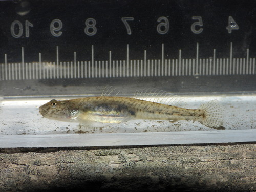

[View on iNaturalist](https://www.inaturalist.org/taxa/117564)

### 7.1.2 Shadow Goby

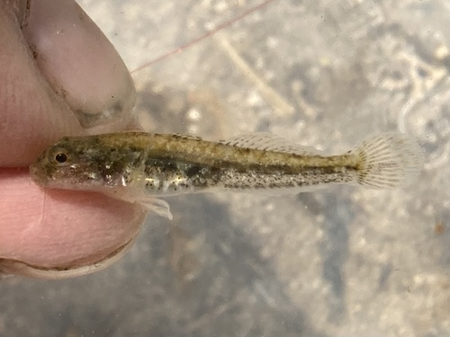

*Quietula y-cauda* - Named for its dark coloration. Common in muddy habitats.

[View on iNaturalist](https://www.inaturalist.org/taxa/111467)

### 7.1.3 Longjaw Mudsucker

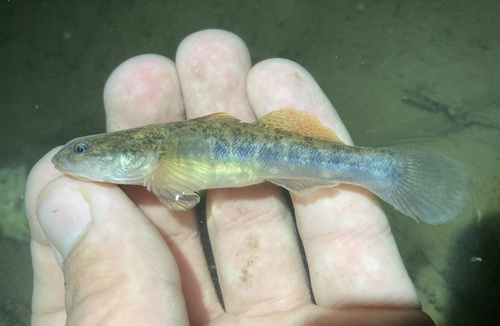

*Gillichthys mirabilis* - Can breathe air through capillaries in its mouth and survive out of water for extended periods! Males provide parental care, guarding eggs in borrowed burrows.

[View on iNaturalist](https://www.inaturalist.org/taxa/101455)

### 7.1.4 Yellowfin Goby

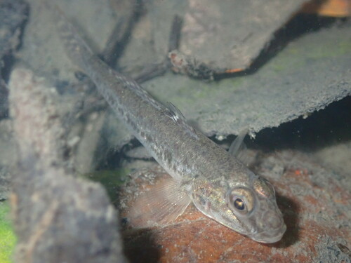

*Acanthogobius flavimanus* - An introduced species from Asia, now common in California estuaries.

[View on iNaturalist](https://www.inaturalist.org/taxa/117563)

## 7.2 Silversides & Killifish

Surface-dwelling schooling fishes that are important prey for larger predators.

### 7.2.1 Topsmelt

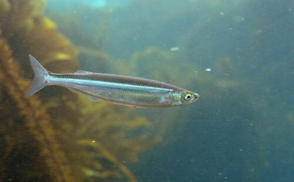

*Atherinops affinis* - A key forage fish species. Forms large schools near the surface.

[View on iNaturalist](https://www.inaturalist.org/taxa/94801)

### 7.2.2 California Killifish

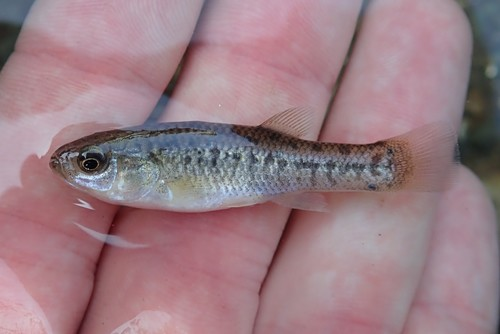

*Fundulus parvipinnis* - Occurs in California and Baja California estuaries; tolerates variable salinity.

[View on iNaturalist](https://www.inaturalist.org/taxa/179533)

## 7.3 Flatfishes

Masters of camouflage that live on the bottom.

### 7.3.1 California Halibut

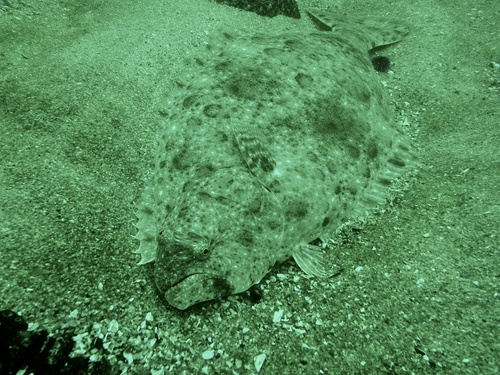

*Paralichthys californicus* - An important commercial and recreational species. Juveniles use shallow coastal and embayment habitats. Individuals may have eyes on either side after metamorphosis.

[View on iNaturalist](https://www.inaturalist.org/taxa/108561)

### 7.3.2 Diamond Turbot

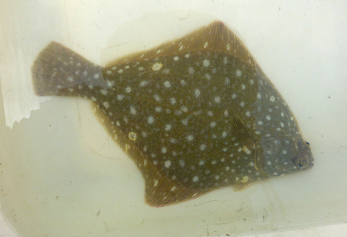

*Hypsopsetta guttulata* - A common small flatfish of bays and estuaries.

[View on iNaturalist](https://www.inaturalist.org/taxa/1316517)

## 7.4 Sharks & Rays

Yes, sharks and rays visit salt marshes! Their occurrence does not establish that reproduction took place at this site.

### 7.4.1 Leopard Shark

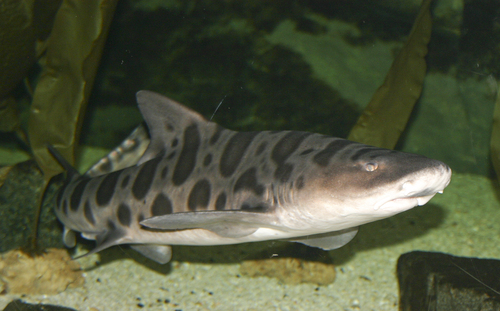

*Triakis semifasciata* - Harmless to humans. Uses shallow coastal and estuarine habitats. A catch does not establish that reproduction occurred at this site.

[View on iNaturalist](https://www.inaturalist.org/taxa/52297)

### 7.4.2 Round Stingray

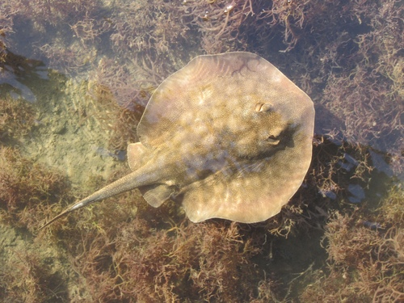

[View on iNaturalist](https://www.inaturalist.org/taxa/114782)

### 7.4.3 Thornback Guitarfish

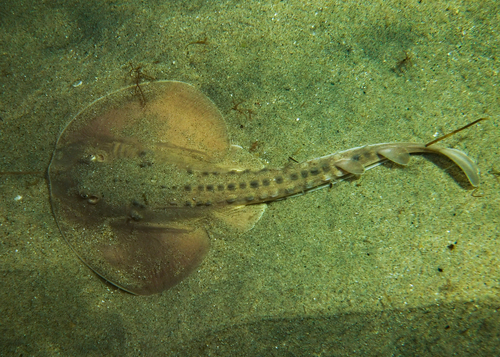

*Platyrhinoidis triseriata* - A ray with an elongated body and broad pectoral disc.

[View on iNaturalist](https://www.inaturalist.org/taxa/48401)

### 7.4.4 Gray Smoothhound

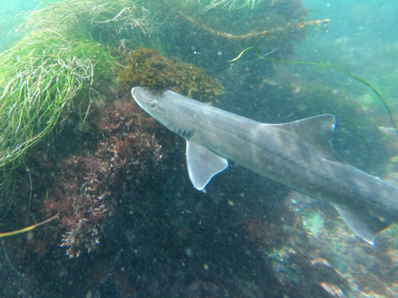

*Mustelus californicus* - A small shark that hunts crabs and shrimp in shallow bays.

[View on iNaturalist](https://www.inaturalist.org/taxa/106254)

## 7.5 Other Notable Species

### 7.5.1 Pacific Staghorn Sculpin

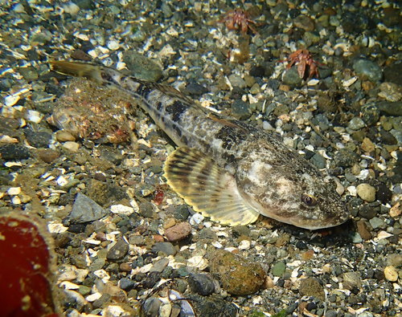

*Leptocottus armatus* - Has sharp spines on its gill covers. Let trained staff handle unfamiliar fish.

[View on iNaturalist](https://www.inaturalist.org/taxa/49163)

### 7.5.2 Shiner Perch

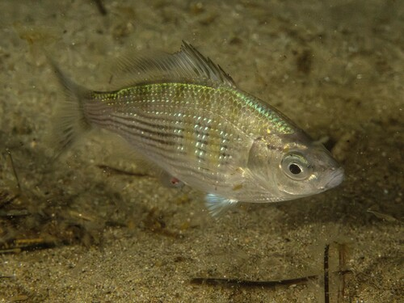

*Cymatogaster aggregata* - Gives live birth! One of many California surfperches.

[View on iNaturalist](https://www.inaturalist.org/taxa/98855)

### 7.5.3 Northern Anchovy

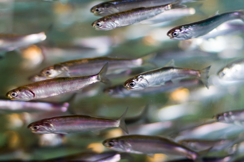

*Engraulis mordax* - A keystone forage species. Feeds whales, seabirds, and larger fish.

[View on iNaturalist](https://www.inaturalist.org/taxa/63770)

### 7.5.4 Opaleye

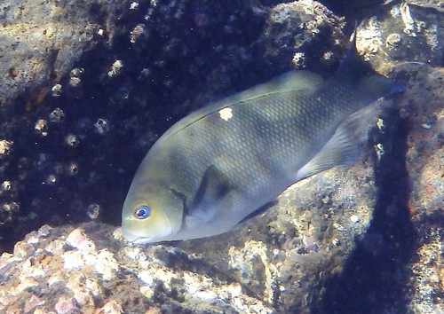

*Girella nigricans* - Named for its beautiful blue-green eyes. Primarily herbivorous.

[View on iNaturalist](https://www.inaturalist.org/taxa/81963)

### 7.5.5 Kelp Bass

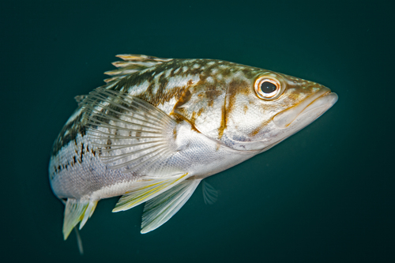

*Paralabrax clathratus* - California’s most popular sport fish. Juveniles use estuaries.

[View on iNaturalist](https://www.inaturalist.org/taxa/108547)

### 7.5.6 Flathead Grey Mullet

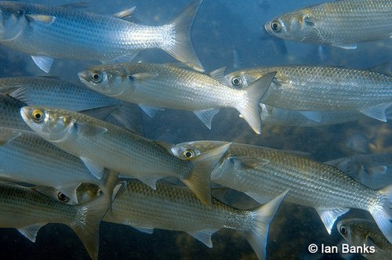

*Mugil cephalus* - A cosmopolitan species found worldwide. Feeds on algae and detritus.

[View on iNaturalist](https://www.inaturalist.org/taxa/106222)

### 7.5.7 Sarcastic Fringehead

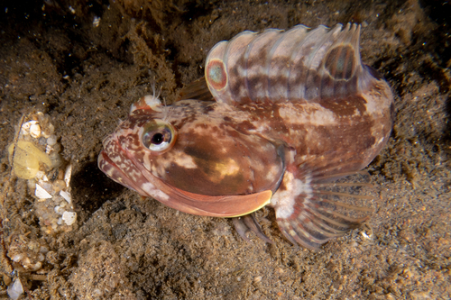

*Neoclinus blanchardi* - Famous for its dramatic territorial displays with enormous jaws!

[View on iNaturalist](https://www.inaturalist.org/taxa/317244)

# 8 Species Profiles

Let’s take a closer look at some key species found in Carpinteria Salt Marsh.

## 8.1 Arrow Goby (*Clevelandia ios*)

```r
arrow_goby <- csm_enclosure %>%
 filter(species_code == "CLIO") %>%
 group_by(year, habitat_code) %>%
 summarize(
   total_count = sum(count, na.rm = TRUE),
   mean_count = mean(count, na.rm = TRUE),
   .groups = "drop"
 )
```

### 8.1.1 Biology

The **Arrow Goby** is a small (< 5 cm) benthic fish endemic to the Pacific coast of North America. Key traits include: - **Habitat:** Soft mud bottoms, often associated with ghost shrimp burrows - **Diet:** Small invertebrates, detritus - **Reproduction:** Males guard eggs in burrow chambers - **Ecological Role:** Important prey for larger fishes and wading birds

### 8.1.2 Abundance Over Time

```r
# Arrow Goby stacked chart - Publication Quality
arrow_goby_wide <- arrow_goby %>%
 mutate(habitat = ifelse(habitat_code == "TC", "Tidal Creek", "Main Channel")) %>%
 pivot_wider(names_from = habitat, values_from = c(total_count, mean_count), values_fill = 0)

highchart() %>%
 hc_chart(type = "column", backgroundColor = "#ffffff") %>%
 hc_title(
   text = "Arrow Goby Annual Abundance",
   style = list(fontSize = "16px", fontWeight = "600")
 ) %>%
 hc_subtitle(
   text = "Total count by habitat (2012–2025)",
   style = list(fontSize = "12px", color = "#666666")
 ) %>%
 hc_xAxis(
   categories = unique(arrow_goby$year),
   labels = list(style = list(fontSize = "11px"))
 ) %>%
 hc_yAxis(
   title = list(text = "Total Individuals", style = list(fontSize = "12px")),
   labels = list(format = "{value:,.0f}"),
   gridLineColor = "#e6e6e6",
   stackLabels = list(enabled = FALSE)
 ) %>%
 hc_plotOptions(column = list(stacking = "normal", borderRadius = 2)) %>%
 hc_add_series(
   name = "Tidal Creek",
   data = arrow_goby %>% filter(habitat_code == "TC") %>% arrange(year) %>% pull(total_count),
   color = "#cb181d"
 ) %>%
 hc_add_series(
   name = "Main Channel",
   data = arrow_goby %>% filter(habitat_code == "BNMC") %>% arrange(year) %>% pull(total_count),
   color = "#2171b5"
 ) %>%
 hc_tooltip(
   shared = TRUE,
   pointFormat = "{series.name}: <b>{point.y:,.0f}</b><br>",
   backgroundColor = "rgba(255,255,255,0.95)",
   borderColor = "#cccccc"
 ) %>%
 hc_legend(
   align = "center",
   verticalAlign = "bottom",
   itemStyle = list(fontSize = "11px")
 ) %>%
 hc_credits(enabled = FALSE)
```

[interactive chart not shown]

## 8.2 California Killifish (*Fundulus parvipinnis*)

```r
killifish <- csm_seine %>%
 filter(species_code == "FUPA") %>%
 group_by(year, habitat_code) %>%
 summarize(
   total_count = sum(count, na.rm = TRUE),
   .groups = "drop"
 )
```

The **California Killifish** is a euryhaline species (tolerant of wide salinity ranges) that is endemic to California and Baja California estuaries.

- **Size:** Up to 11 cm
- **Diet:** Invertebrates, algae, detritus
- **Special Adaptation:** Can tolerate salinities from fresh water to >100 ppt
- **Behavior:** Forms schools in shallow areas

```r
# California Killifish grouped bar chart - Publication Quality
killifish %>%
 mutate(habitat = ifelse(habitat_code == "TC", "Tidal Creek", "Main Channel")) %>%
 plot_ly(x = ~year, y = ~total_count, color = ~habitat,
         colors = c("#2171b5", "#cb181d"),
         type = "bar",
         hoverinfo = "text",
         text = ~paste0("Year: ", year, "<br>",
                       "Habitat: ", habitat, "<br>",
                       "Count: ", comma(total_count))) %>%
 layout(
   title = list(
     text = "California Killifish Annual Abundance",
     font = list(size = 16, family = "Helvetica Neue, Arial", color = "#1a1a1a")
   ),
   barmode = "group",
   xaxis = list(
     title = list(text = "Year", font = list(size = 12)),
     tickfont = list(size = 11)
   ),
   yaxis = list(
     title = list(text = "Total Individuals", font = list(size = 12)),
     tickfont = list(size = 11),
     gridcolor = "#e6e6e6",
     rangemode = "tozero"
   ),
   legend = list(
     orientation = "h", y = -0.15, x = 0.5, xanchor = "center",
     font = list(size = 11)
   ),
   plot_bgcolor = "#ffffff",
   paper_bgcolor = "#ffffff"
 )
```

[interactive chart not shown]

## 8.3 Topsmelt (*Atherinops affinis*)

```r
topsmelt <- csm_seine %>%
 filter(species_code == "ATAF") %>%
 group_by(year) %>%
 summarize(
   total_count = sum(count, na.rm = TRUE),
   .groups = "drop"
 )
```

**Topsmelt** are schooling silversides that are abundant in California bays and estuaries.

- **Size:** Up to 37 cm (commonly 15-25 cm)
- **Diet:** Zooplankton, small invertebrates, algae
- **Reproduction:** Spawns in eelgrass and algae beds
- **Fishery:** Important forage fish for seabirds and larger predators

```r
# Topsmelt area chart - Publication Quality
highchart() %>%
 hc_chart(type = "areaspline", backgroundColor = "#ffffff") %>%
 hc_title(
   text = "Topsmelt Annual Abundance",
   style = list(fontSize = "16px", fontWeight = "600")
 ) %>%
 hc_subtitle(
   text = "Note the extreme interannual variability",
   style = list(fontSize = "12px", color = "#666666")
 ) %>%
 hc_xAxis(
   categories = topsmelt$year,
   labels = list(style = list(fontSize = "11px"))
 ) %>%
 hc_yAxis(
   title = list(text = "Total Individuals", style = list(fontSize = "12px")),
   labels = list(format = "{value:,.0f}"),
   gridLineColor = "#e6e6e6",
   min = 0
 ) %>%
 hc_add_series(
   name = "Topsmelt",
   data = topsmelt$total_count,
   color = "#fe9929",
   fillColor = list(
     linearGradient = list(x1 = 0, y1 = 0, x2 = 0, y2 = 1),
     stops = list(c(0, "rgba(254,153,41,0.5)"), c(1, "rgba(254,153,41,0.05)"))
   ),
   lineWidth = 2,
   marker = list(radius = 4, symbol = "circle")
 ) %>%
 hc_tooltip(
   pointFormat = "Year {point.category}: <b>{point.y:,.0f}</b> individuals",
   backgroundColor = "rgba(255,255,255,0.95)",
   borderColor = "#cccccc"
 ) %>%
 hc_legend(enabled = FALSE) %>%
 hc_credits(enabled = FALSE)
```

[interactive chart not shown]

# 9 Ecological Guilds

Fish species can be grouped into **ecological guilds** based on their habitat use and life history strategies. The provisional assignments below cover only a subset of taxa; unassigned catches are excluded from the denominator. A marine migrant is not necessarily a juvenile or a nursery user.

```r
# Assign guilds to key species
guild_assignments <- tribble(
 ~species_code, ~guild, ~description,
 "CLIO", "Resident", "Spends entire life in estuary",
 "ILGI", "Resident", "Spends entire life in estuary",
 "QUYC", "Resident", "Spends entire life in estuary",
 "GIMI", "Resident", "Spends entire life in estuary",
 "FUPA", "Resident", "Spends entire life in estuary",
 "ATAF", "Marine Migrant", "Uses estuary seasonally",
 "PACA", "Marine Migrant", "Juvenile nursery habitat",
 "HYGU", "Marine Migrant", "Juvenile nursery habitat",
 "SYLE", "Resident", "Spends entire life in estuary",
 "MUCE", "Marine Migrant", "Adults enter to feed",
 "MYCA", "Marine Migrant", "Foraging habitat",
 "ANCO", "Marine Migrant", "Uses estuary seasonally"
)

# Calculate proportions by guild from seine data
guild_summary <- csm_seine %>%
 left_join(guild_assignments, by = "species_code") %>%
 filter(!is.na(guild)) %>%
 group_by(year, guild) %>%
 summarize(total_count = sum(count, na.rm = TRUE), .groups = "drop") %>%
 group_by(year) %>%
 mutate(proportion = total_count / sum(total_count) * 100)
```

```r
# Ecological guild stacked area chart - Publication Quality
highchart() %>%
 hc_chart(type = "area", backgroundColor = "#ffffff") %>%
 hc_title(
   text = "Ecological Guild Composition",
   style = list(fontSize = "16px", fontWeight = "600")
 ) %>%
 hc_subtitle(
   text = "Catch proportions among assigned resident and migrant taxa (2012–2025)",
   style = list(fontSize = "12px", color = "#666666")
 ) %>%
 hc_xAxis(
   categories = unique(guild_summary$year),
   labels = list(style = list(fontSize = "11px"))
 ) %>%
 hc_yAxis(
   title = list(text = "Proportion of Catch", style = list(fontSize = "12px")),
   max = 100,
   labels = list(format = "{value}%", style = list(fontSize = "11px")),
   gridLineColor = "#e6e6e6"
 ) %>%
 hc_plotOptions(
   area = list(
     stacking = "percent",
     lineWidth = 1,
     marker = list(enabled = FALSE)
   )
 ) %>%
 hc_add_series(
   name = "Resident",
   data = guild_summary %>% filter(guild == "Resident") %>% arrange(year) %>% pull(total_count),
   color = "#238b45",
   fillOpacity = 0.7
 ) %>%
 hc_add_series(
   name = "Marine Migrant",
   data = guild_summary %>% filter(guild == "Marine Migrant") %>% arrange(year) %>% pull(total_count),
   color = "#2171b5",
   fillOpacity = 0.7
 ) %>%
 hc_tooltip(
   shared = TRUE,
   pointFormat = "{series.name}: <b>{point.percentage:.1f}%</b> ({point.y:,.0f})<br>",
   backgroundColor = "rgba(255,255,255,0.95)",
   borderColor = "#cccccc"
 ) %>%
 hc_legend(
   align = "center",
   verticalAlign = "bottom",
   itemStyle = list(fontSize = "11px")
 ) %>%
 hc_credits(enabled = FALSE)
```

[interactive chart not shown]

# 10 Summary Statistics

## 10.1 Overall Community Summary

```r
overall_stats <- csm_ps %>%
 summarize(
   `Years of Data` = paste(min(year), "-", max(year)),
   `Total Sampling Events` = n(),
   `Mean Density (fish/m²)` = round(mean(count_per_m2), 2),
   `Max Density (fish/m²)` = round(max(count_per_m2), 2),
   `Mean Species Richness` = round(mean(species_count), 1),
   `Max Species Richness` = max(species_count)
 )

# Create nice summary cards with HTML
div(class = "row",
   div(class = "col-md-4",
       div(class = "panel panel-primary",
           div(class = "panel-heading", "Years of Monitoring"),
           div(class = "panel-body", style = "font-size: 24px; text-align: center;",
               overall_stats$`Years of Data`))),
   div(class = "col-md-4",
       div(class = "panel panel-success",
           div(class = "panel-heading", "Mean Fish Density"),
           div(class = "panel-body", style = "font-size: 24px; text-align: center;",
               paste(overall_stats$`Mean Density (fish/m²)`, "fish/m²")))),
   div(class = "col-md-4",
       div(class = "panel panel-info",
           div(class = "panel-heading", "Mean Species Richness"),
           div(class = "panel-body", style = "font-size: 24px; text-align: center;",
               paste(overall_stats$`Mean Species Richness`, "species"))))
)
```

**Years of Monitoring**

2012 - 2025

**Mean Fish Density**

24.6 fish/m²

**Mean Species Richness**

8.6 species

## 10.2 Species Summary by Abundance Category

```r
# Categorize species by abundance
all_species_counts <- bind_rows(
 csm_enclosure %>%
   group_by(species_code) %>%
   summarize(total = sum(count), .groups = "drop"),
 csm_seine %>%
   group_by(species_code) %>%
   summarize(total = sum(count), .groups = "drop")
) %>%
 group_by(species_code) %>%
 summarize(total = sum(total), .groups = "drop") %>%
 filter(total > 0) %>%
 left_join(common_names, by = "species_code") %>%
 mutate(
   category = case_when(
     total > 10000 ~ "Dominant (>10,000)",
     total > 1000 ~ "Common (1,000-10,000)",
     total > 100 ~ "Moderate (100-1,000)",
     total > 10 ~ "Uncommon (10-100)",
     TRUE ~ "Rare (<10)"
   )
 )

category_summary <- all_species_counts %>%
 group_by(category) %>%
 summarize(
   `Number of Species` = n(),
   `Total Individuals` = sum(total),
   .groups = "drop"
 ) %>%
 arrange(desc(`Total Individuals`))

# Pie chart of abundance categories - Publication Quality
# Define custom colors for categories
category_colors <- c(
  "Dominant (>10,000)" = "#08519c",
  "Common (1,000-10,000)" = "#3182bd",
  "Moderate (100-1,000)" = "#6baed6",
  "Uncommon (10-100)" = "#9ecae1",
  "Rare (<10)" = "#c6dbef"
)

highchart() %>%
 hc_chart(type = "pie", backgroundColor = "#ffffff") %>%
 hc_title(
   text = "Species Distribution by Abundance",
   style = list(fontSize = "16px", fontWeight = "600")
 ) %>%
 hc_subtitle(
   text = "Number of species in each abundance category",
   style = list(fontSize = "12px", color = "#666666")
 ) %>%
 hc_add_series(
   name = "Species",
   data = list_parse(
     category_summary %>%
       transmute(
         name = category,
         y = `Number of Species`,
         individuals = `Total Individuals`,
         color = category_colors[category]
       )
   ),
   innerSize = "40%"
 ) %>%
 hc_tooltip(
   pointFormat = "<b>{point.name}</b><br>Species count: <b>{point.y}</b><br>Total individuals: <b>{point.individuals:,.0f}</b>",
   backgroundColor = "rgba(255,255,255,0.95)",
   borderColor = "#cccccc"
 ) %>%
 hc_plotOptions(
   pie = list(
     allowPointSelect = TRUE,
     cursor = "pointer",
     dataLabels = list(
       enabled = TRUE,
       format = "{point.name}: {point.y}",
       style = list(fontSize = "11px", fontWeight = "500", textOutline = "none")
     ),
     showInLegend = FALSE
   )
 ) %>%
 hc_credits(enabled = FALSE)
```

[interactive chart not shown]

# 11 Key Takeaways

## 11.1 What We’ve Learned About Carpinteria Salt Marsh Fishes

1. **High Diversity:** **43 taxon entries with positive catches** were recorded at Carpinteria Salt Marsh; these include unresolved identifications, from tiny gobies to large elasmobranchs
2. **Enclosure Catches:** Arrow goby is the most numerous named species in enclosure catches. Seine and enclosure totals cannot be compared as whole-marsh abundances.
3. **Habitat Partitioning:** Tidal creeks and main channels support different fish densities and compositions
4. **Temporal Variability:** Estimated density and catch composition differ among years. These summaries do not identify environmental causes.
5. **Estuarine Specialists:** Resident and visiting fishes are both represented; catch proportions depend on the sampling method

## 11.2 Discussion Questions

1. Why are gobies so abundant in salt marshes compared to other habitats?
2. How might climate change affect salt marsh fish communities?
3. What is the value of long-term monitoring datasets like this one?
4. How do sampling methods influence our perception of community composition?

# 12 Interpretation and Data Revision

This update uses EDI packages **edi.647.9** and **edi.648.9**. Authenticated EDI revision-list checks on 26 October 2026 confirmed these are the latest available revisions; remote EML matches the cached metadata. The original files are read from the shared catalogue cache; hashes, schema checks and the verification timestamp are recorded in `data/metadata/current_sources.json`. Historical revision-8 files remain unchanged.

The performance table contains annual location summaries, combining method-specific estimates under the published protocol. Repeated samples of the same location are not independent replicates. Raw seine and enclosure catches must remain separate when comparing abundance. Summed catch is not a whole-marsh population estimate.

Taxon inventories contain unresolved family or genus identifications as well as named species. A sampling-month comparison is not evidence of seasonality because the annual survey calendar is uneven. Catch identity alone does not establish juvenile nursery use. The separate dashboard’s legacy Gaussian models are exploratory and have residual and dependence problems; they are not validated inferential results.

# 13 References & Further Reading

- SONGS wetland fish survey, EDI revision 9 (2026): [data and metadata](https://doi.org/10.6073/pasta/57c6811e9ded961fbd5bdfaa074d6d9f).
- SONGS annual wetland fish abundance and richness, EDI revision 9 (2026): [data and metadata](https://doi.org/10.6073/pasta/fd7423338030a23118de2d5c1ff2aa5e).
- Allen, L.G., M.H. Horn, F.A. Edmands II, and C.A. Usui. 1983. Structure and seasonal dynamics of the fish assemblage in the Cabrillo Beach area of Los Angeles Harbor, California. *Bulletin of the Southern California Academy of Sciences* 82:47-70.
- Horn, M.H., and L.G. Allen. 1985. Fish community ecology in southern California bays and estuaries. Pages 169-190 *in* A. Yanez-Arancibia, editor. Fish community ecology in estuaries and coastal lagoons: Towards ecosystem integration. UNAM Press, Mexico City.
- Steele, M.A., S.C. Schroeter, and H.M. Page. 2006. Sampling characteristics and biases of enclosure traps for sampling fishes in estuaries. *Estuaries and Coasts* 29:630-638.
- SONGS Mitigation Monitoring Program: http://marinemitigation.msi.ucsb.edu/

*Report generated on 2026-10-26 using R version R version 4.6.1 (2026-06-24)*